# CDA Homework 3

Joshua Ingram

September 23, 2019

## 1. Inference for a Proportion

### a)

1.8

```r
n <- 1374
count <- 486
prop <- count/n

lower <- prop - 2.576 * sqrt((prop * (1-prop))/n)
upper <- prop + 2.576 * sqrt((prop * (1-prop))/n)

lower
```

```
## [1] 0.3204848
```

```r
upper
```

```
## [1] 0.3869387
```

We are 99% confident that the true population proportion of people in the US in 2010 that would be willing to accept cuts in their standard of living to protect the environment is between .3205 and .3869.

2. HO: $\hat{\pi}$ = .50 HA: $\hat{\pi}$ =/= .50 $\alpha$ = .01

```r
z <- (prop - .50) / sqrt((prop * (1-prop))/n)
z
```

```
## [1] -11.34135
```

```r
pnorm(z) * 2
```

```
## [1] 8.187032e-30
```

### b)

1.8 (same hypothesis test as in in the last part)

```r
prop.test(486, 1374, alternative = "two.sided", conf.level = .99)
```

```
##
##  1-sample proportions test with continuity correction
##
## data:  486 out of 1374, null probability 0.5
## X-squared = 117.03, df = 1, p-value < 2.2e-16
## alternative hypothesis: true p is not equal to 0.5
## 99 percent confidence interval:
##  0.3209081 0.3879369
## sample estimates:
##         p
## 0.3537118
```

1. We are 99% confident that the true population proportion of people in the US in 2010 that would be willing to accept cuts in their standard of living to protect the environment is between .3209 and .3879
2. With $\alpha$ at .01, we received a p-value of 2.2e-16, so we have significant evidence to reject the null hypthesis, that a half of the population would be willing to take cuts, in favor of the alternative hypothesis, that either a minority or majority of the population would be willing to take cuts in their standard of living to protect the environment. Based on our confidence interval, we can see that we have significant evidence to believe that a minoirty of the population would be willing to take these cuts.

## 2. Likelihood Inference for a single observation from a Poisson Distribution

### a)

P(Y = y) = ($\lambda^y$ * $e^{-\lambda}$) / y!

### b)

l($\lambda$; y) = P(Y = y) = ($\lambda^y$ * $e^{-\lambda}$) / y!

### c)

L($\lambda$; y) = log[($\lambda^y$ * $e^{-\lambda}$) / y!]

### d)

```r
likelihoods <- c()
for (i in 1:15){
  like <- log((i^4 * 2.71828^(-i))/24)
      likelihoods <- append(likelihoods, like)
}
likelihoods
```

```
##  [1] -4.178053 -2.405464 -1.783603 -1.632874 -1.740299 -2.011012 -2.394409
##  [8] -2.860282 -3.389149 -3.967707 -4.586465 -5.238419 -5.918248 -6.621815
## [15] -7.345843
```

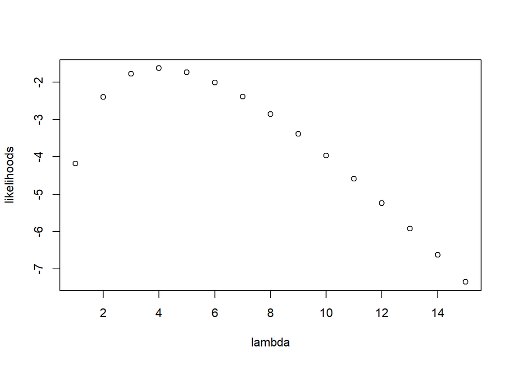

```r
plot(likelihoods~c(1:15), xlab = "lambda")
```

### e)

(after chain rule and product rule)

the derivative of our original function is:

(24/($\lambda^4$ e^-$\lambda$)) * ((1/6) $\lambda^3$ e^-$\lambda$ - (1/24) e^-$\lambda$ $\lambda^4$)

setting this equal to 0, we find where the maximum is… which is at $\lambda$ = 4 the MLE of $\lambda$ would be 4